← AN05B023a-d scenes

# Bristle types and neuromeres: the drive onto dimorphic neurons

## The question

Which contact chemosensory bristle types drive the sexually dimorphic neurons? Which neuromeres do this?

Related pages: do the targets group the bristle types, the ascending ranking, the AN05B023 family by volume, and the scene pages for AN05B023a-d, AN05B102 and AN09B017. AN09B017 takes its input from LgLG5, LgLG6, LgLG7 and LgLG8, which are the four types that lead this page per cell.

```r
options(rgl.useNULL = TRUE)   # must precede any library that pulls rgl in (nat)

suppressMessages({
  library(neuprintr); library(malecns); library(nat)
  library(coconatfly); library(coconat); library(Matrix)
  options(malecns.dataset = "male-cns:v1.0")   # malecns helpers ignore MCNS_DATASET
  library(dplyr); library(tibble)
  library(ggplot2); library(ggrepel); library(scales); library(patchwork)
})

R_DIR <- "/Users/fkampf/Documents/pheromone.paper/analyses/an_investigation/R"

Sys.setenv(AN_CASE = "an05b023bc")   # only for the palettes
source(file.path(R_DIR, "_paths.R"))
source(file.path(R_DIR, "_an_pair.R"))
source(file.path(R_DIR, "_bristle_impact.R"))
neuprint_login(server = MCNS_SERVER, dataset = MCNS_DATASET)
```

```r
load_once <- function(name, expr, envir = .GlobalEnv) {
  # eval() here evaluates a quote()d expression written literally in this file -
  # a lazy-evaluation idiom for "only fetch if not already cached", not a parser
  # of external input.
  if (!exists(name, envir = envir, inherits = FALSE)) {
    assign(name, eval(expr), envir = envir)
  }
  get(name, envir = envir)
}

mba  <- load_once("mba", quote(mcns_body_annotations()))
pool <- sensory_pool(mba)
```

## The unit

Read this section before the figures. The bars are not synapse counts.

One synapse count becomes a fraction: the page divides every edge by the whole input of the cell that receives it. One entry is therefore the share of one dimorphic cell’s input.

The page then adds these shares up, over the cells of a dimorphic type, and over the types. **One bar is a number of whole dimorphic cells’ worth of input.** A bar of 3 means this bristle group supplies as much input as three dimorphic cells receive in total. The drive is spread over many cells, and no single cell gives more than 1.

`eff` is that number for the whole bristle group. `eff_per_cell` is the same number divided by the count of bristle cells in the group. The first says what the group delivers. The second says what one bristle cell delivers, and it removes the difference in cell counts: the wing holds 385 cells and T1 holds 264.

A volume restricts the numerator AND the denominator. Inside the brain a dimorphic cell receives far less input, so one synapse is a larger share of it. **Compare the groups inside one volume. Do not compare a number in the brain with a number in the whole reconstruction.**

## The method

The bristles almost never touch a dimorphic neuron directly, so the page measures two routes and keeps them apart.

The direct route is one synapse. A bristle contacts a dimorphic neuron.

The one hop route is two synapses. A bristle contacts an interneuron, and that interneuron contacts a dimorphic neuron. The weight of the path is the product of the two shares: the share of the interneuron’s input that comes from the bristle, and the share of the dimorphic cell’s input that comes from the interneuron.

`coconat::effective_connectivity()` multiplies the hops and aligns them by name, so a path that stops early becomes zero. The function comes from natverse/coconat and natverse/coconatfly PR 59 uses it for the same purpose.

The scaling is done in `_bristle_impact.R` and not by `colScaleM()`. That function divides a column by the column sum of the matrix it receives. These matrices hold one presynaptic population, and not every input a cell receives, so that function would call an interneuron with five bristle synapses out of five thousand fully bristle driven. Each hop here is divided by the true whole input of its postsynaptic cell, fetched for that volume.

```r
by_type    <- load_once("by_type",    quote(bristle_impact(mba, pool, by = "type")))
by_segment <- load_once("by_segment", quote(bristle_impact(mba, pool, by = "segment")))
by_type_t1 <- load_once("by_type_t1",
                        quote(bristle_impact(mba, pool, by = "type", segment = "T1")))

by_type$mids
```

| vol | n_mids | n_mids_kept | min_frac |
| --- | --- | --- | --- |
| whole | 1885 | 1129 | 0.005 |
| CentralBrain | 484 | 406 | 0.005 |
| VNC | 1862 | 1158 | 0.005 |

An interneuron enters the one hop route if the bristles reach it and it reaches a dimorphic neuron. `min_frac` then drops an interneuron that takes less than 0.5 percent of its whole input from the bristles. In the whole reconstruction this keeps 1129 of 1885 interneurons.

The one hop route is a choice. It is not the truth. A path of three synapses also exists, and this page does not measure it.

## The direct route and the one hop route

```r
by_type$tab |>
  summarise(eff = sum(eff), types = sum(n_types), .by = c(vol, route)) |>
  arrange(vol, route)
```

| vol | route | eff | types |
| --- | --- | --- | --- |
| whole reconstruction | direct | 11.30701 | 145 |
| whole reconstruction | one hop | 23.69948 | 5510 |
| brain | one hop | 191.53430 | 5129 |
| nerve cord | direct | 15.46144 | 145 |
| nerve cord | one hop | 5.44704 | 1209 |

In the whole reconstruction the direct route gives 11.3 and the one hop route gives 23.7. The one hop route holds 68 percent of the modelled drive. The figures below show the one hop route.

## Which neuromere

```r
by_segment$tab |>
  filter(route == "one hop") |>
  summarise(eff = sum(eff), per_cell = sum(eff_per_cell),
            cells = first(cells), .by = c(vol, grp)) |>
  arrange(vol, desc(eff))
```

| vol | grp | eff | per_cell | cells |
| --- | --- | --- | --- | --- |
| whole reconstruction | T1 | 16.6310999 | 0.062996590 | 264 |
| whole reconstruction | wing | 3.3933069 | 0.008813784 | 385 |
| whole reconstruction | T3 | 1.8477501 | 0.008634346 | 214 |
| whole reconstruction | T2 | 1.8273233 | 0.008957467 | 204 |
| brain | T1 | 77.5907488 | 0.293904352 | 264 |
| brain | wing | 50.9555354 | 0.132352040 | 385 |
| brain | T3 | 32.6373068 | 0.152510780 | 214 |
| brain | T2 | 30.3507134 | 0.148778007 | 204 |
| nerve cord | T1 | 3.1114163 | 0.011785668 | 264 |
| nerve cord | wing | 1.0568831 | 0.002745151 | 385 |

[output cut: 2 more lines]

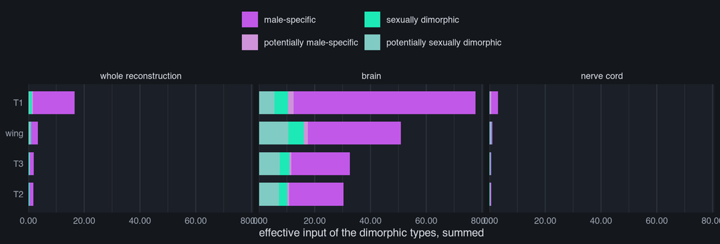

```r
impact_plot(by_segment, route = "one hop", measure = "eff")
```

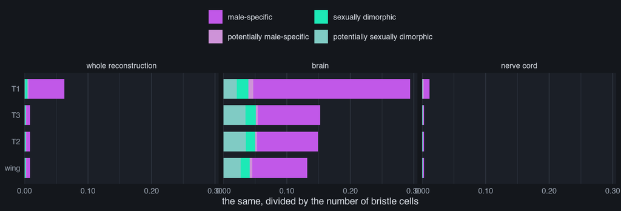

```r
impact_plot(by_segment, route = "one hop", measure = "eff_per_cell")
```

T1 gives the most drive, and it gives more than the wing, T2 and T3 together. Per cell it gives about seven times what a wing cell gives.

## Which bristle type

```r
by_type$tab |>
  filter(route == "one hop", vol == "whole reconstruction") |>
  summarise(eff = sum(eff), per_cell = sum(eff_per_cell),
            types = sum(n_types), cells = first(cells), .by = grp) |>
  arrange(desc(eff))
```

| grp | eff | per_cell | types | cells |
| --- | --- | --- | --- | --- |
| LgLG6 | 5.50559618 | 0.344099761 | 386 | 16 |
| LgLG5 | 3.44432283 | 0.264947910 | 390 | 13 |
| LgLG8 | 2.89023445 | 0.206445318 | 363 | 14 |
| LgLG1a | 2.47913142 | 0.018228908 | 421 | 136 |
| LgLG1b | 1.86629802 | 0.013927597 | 414 | 134 |
| LgLG7 | 1.75171846 | 0.083415165 | 319 | 21 |
| LgLG2 | 1.33705235 | 0.010364747 | 387 | 129 |
| WG1 | 1.18999086 | 0.012395738 | 371 | 96 |
| LgLG3 | 0.91382645 | 0.005640904 | 408 | 162 |
| WG3 | 0.90002084 | 0.009375217 | 388 | 96 |

[output cut: 5 more lines]

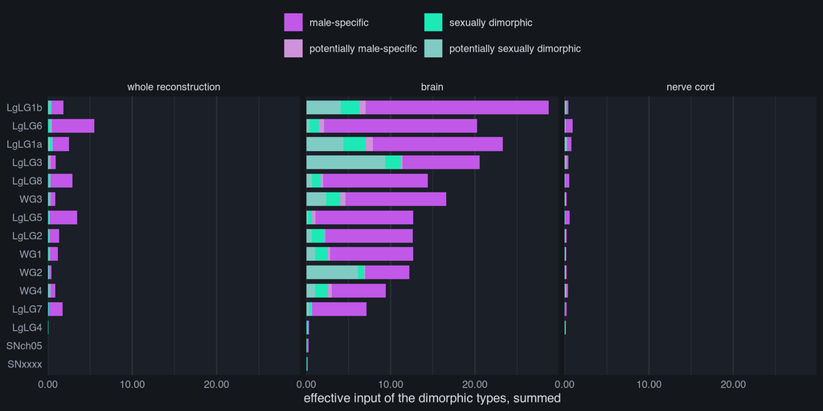

```r
impact_plot(by_type, route = "one hop", measure = "eff")
```

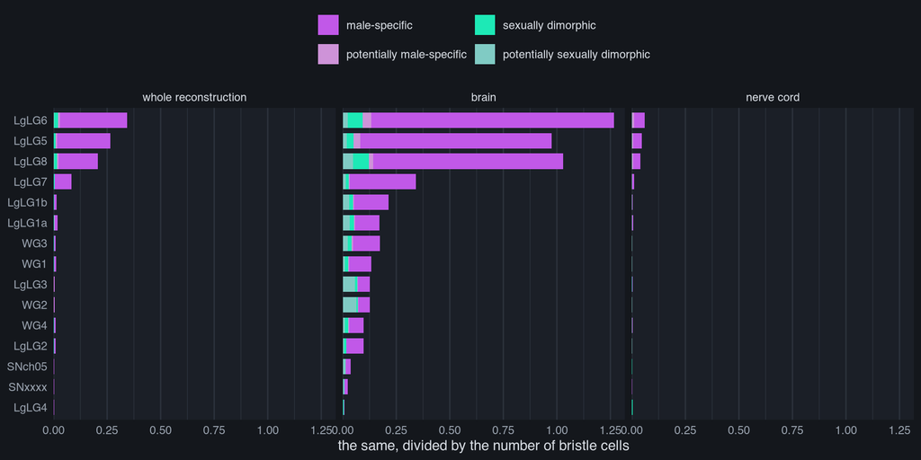

```r
impact_plot(by_type, route = "one hop", measure = "eff_per_cell")
```

LgLG6, LgLG5 and LgLG8 lead both figures. They hold 16, 13 and 14 cells. LgLG1a holds 136 cells and gives less than LgLG6.

All three of these types enter through the prothoracic nerve, and they are the types that make T1 the strongest neuromere.

## The T1 cells alone

The types above hold cells in more than one neuromere. LgLG1a holds 34 cells in T1, 50 in T2 and 52 in T3. This section keeps the T1 cells of every type and drops the rest, so the comparison is inside one neuromere.

```r
by_type_t1$tab |>
  filter(route == "one hop", vol == "whole reconstruction") |>
  summarise(eff = sum(eff), per_cell = sum(eff_per_cell),
            cells = first(cells), .by = grp) |>
  arrange(desc(eff))
```

| grp | eff | per_cell | cells |
| --- | --- | --- | --- |
| LgLG6 | 5.503828460 | 0.343989279 | 16 |
| LgLG5 | 3.442272536 | 0.264790195 | 13 |
| LgLG8 | 2.890140342 | 0.206438596 | 14 |
| LgLG7 | 1.751430517 | 0.083401453 | 21 |
| LgLG1a | 1.312622597 | 0.038606547 | 34 |
| LgLG1b | 0.812275069 | 0.021375660 | 38 |
| LgLG3 | 0.438929253 | 0.007439479 | 59 |
| LgLG2 | 0.421909135 | 0.009171938 | 46 |
| LgLG4 | 0.025114034 | 0.001674269 | 15 |
| SNxxxx | 0.021470946 | 0.003067278 | 7 |

[output cut: 1 more lines]

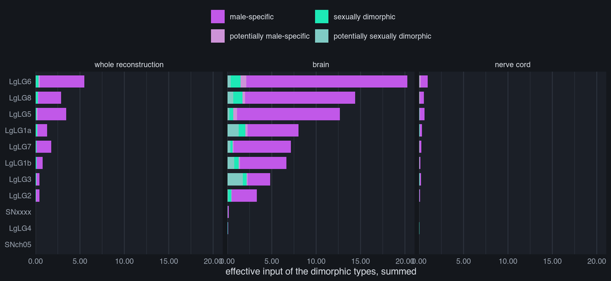

```r
impact_plot(by_type_t1, route = "one hop", measure = "eff")
```

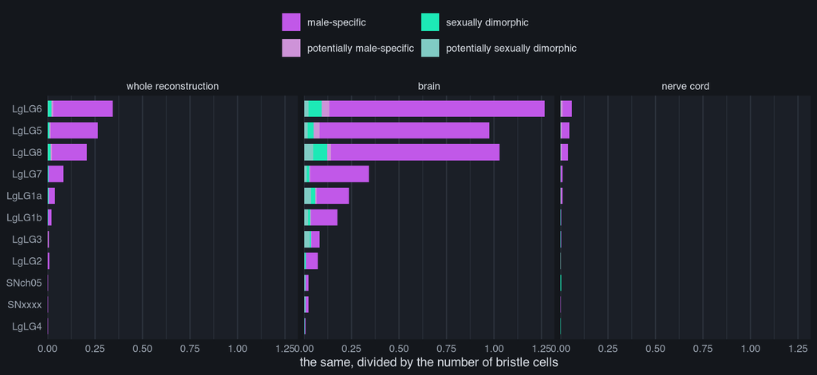

```r
impact_plot(by_type_t1, route = "one hop", measure = "eff_per_cell")
```

## How many dimorphic types each group reaches

Strength is not reach. A bristle type can give much drive to a few dimorphic types, or a little drive to many.

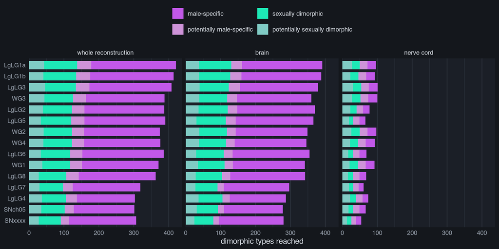

```r
impact_reach_plot(by_type, route = "one hop")
```

## What this page does not show

The receptor identity of these bristle types is not settled. It is a light level call. Do not read this page as a statement about ppk23 or about ppk25.

The one hop route is a model. The page counts two synapses and no more.

A truncated neuron is not comparable with a complete neuron. AN05B023b is truncated in the brain: its whole brain output is 57 synapses. `08_an05b023bc_cut.Rmd` shows this cut.

The dimorphism annotation is incomplete. The page uses the four annotated classes, and it drops every neuron with no annotation.